# Week 2 Lab

SeungHeonDoh 2018/02/21

```r
library(stats)
library(dplyr)
library(ggplot2)
```

### Data Description

The data frame containing 32735 flights that shows up in your workspace is a data matrix, with each row representing an observation and each column representing a variable. R calls this data format a data frame, which is a term that will be used throughout the labs.

#### Data load

```r
load(url("https://stat.duke.edu/~mc301/data/nycflights.RData"))
```

```r
names(nycflights)
```

```
##  [1] "year"      "month"     "day"       "dep_time"  "dep_delay"
##  [6] "arr_time"  "arr_delay" "carrier"   "tailnum"   "flight"
## [11] "origin"    "dest"      "air_time"  "distance"  "hour"
## [16] "minute"
```

- year, month, day: Date of departure
- dep_time, arr_time: Departure and arrival times, local timezone.
- dep_delay, arr_delay: Departure and arrival delays, in minutes. Negative times represent early departures/arrivals.
- carrier: Two letter carrier abbreviation.
  - 9E: Endeavor Air Inc.
  - AA: American Airlines Inc.
  - AS: Alaska Airlines Inc.
  - B6: JetBlue Airways
  - DL: Delta Air Lines Inc.
  - EV: ExpressJet Airlines Inc.
  - F9: Frontier Airlines Inc.
  - FL: AirTran Airways Corporation
  - HA: Hawaiian Airlines Inc.
  - MQ: Envoy Air
  - OO: SkyWest Airlines Inc.
  - UA: United Air Lines Inc.
  - US: US Airways Inc.
  - VX: Virgin America
  - WN: Southwest Airlines Co.
  - YV: Mesa Airlines Inc.
- tailnum: Plane tail number
- flight: Flight number
- origin, dest: Airport codes for origin and destination. (Google can help you with what code stands for which airport.)
- air_time: Amount of time spent in the air, in minutes.
- distance: Distance flown, in miles.

#### viewing its dimensions and data types is str, which stands for structure.

```r
str(nycflights)
```

```
## Classes 'tbl_df' and 'data.frame':   32735 obs. of  16 variables:
##  $ year     : int  2013 2013 2013 2013 2013 2013 2013 2013 2013 2013 ...
##  $ month    : int  6 5 12 5 7 1 12 8 9 4 ...
##  $ day      : int  30 7 8 14 21 1 9 13 26 30 ...
##  $ dep_time : int  940 1657 859 1841 1102 1817 1259 1920 725 1323 ...
##  $ dep_delay: num  15 -3 -1 -4 -3 -3 14 85 -10 62 ...
##  $ arr_time : int  1216 2104 1238 2122 1230 2008 1617 2032 1027 1549 ...
##  $ arr_delay: num  -4 10 11 -34 -8 3 22 71 -8 60 ...
##  $ carrier  : chr  "VX" "DL" "DL" "DL" ...
##  $ tailnum  : chr  "N626VA" "N3760C" "N712TW" "N914DL" ...
##  $ flight   : int  407 329 422 2391 3652 353 1428 1407 2279 4162 ...
##  $ origin   : chr  "JFK" "JFK" "JFK" "JFK" ...
##  $ dest     : chr  "LAX" "SJU" "LAX" "TPA" ...
##  $ air_time : num  313 216 376 135 50 138 240 48 148 110 ...
##  $ distance : num  2475 1598 2475 1005 296 ...
##  $ hour     : num  9 16 8 18 11 18 12 19 7 13 ...
##  $ minute   : num  40 57 59 41 2 17 59 20 25 23 ...
```

#### This function says to plot the dep_delay variable from the nycflights data frame on the x-axis. It also defines a geom (short for geometric object), which describes the type of plot you will produce.

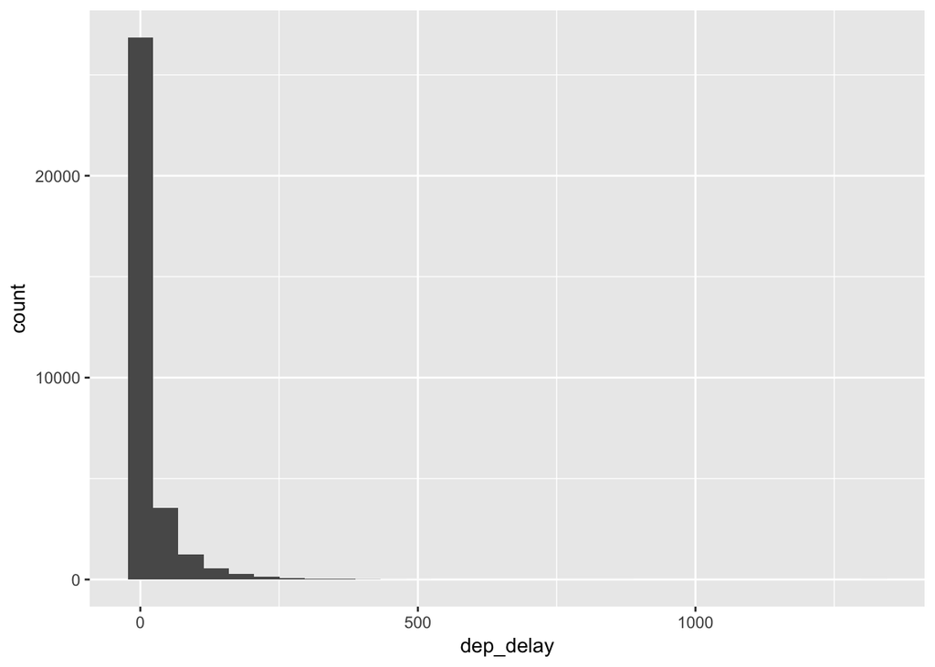

```r
ggplot(data = nycflights, aes(x = dep_delay)) +geom_histogram()
```

#### Check certain columns

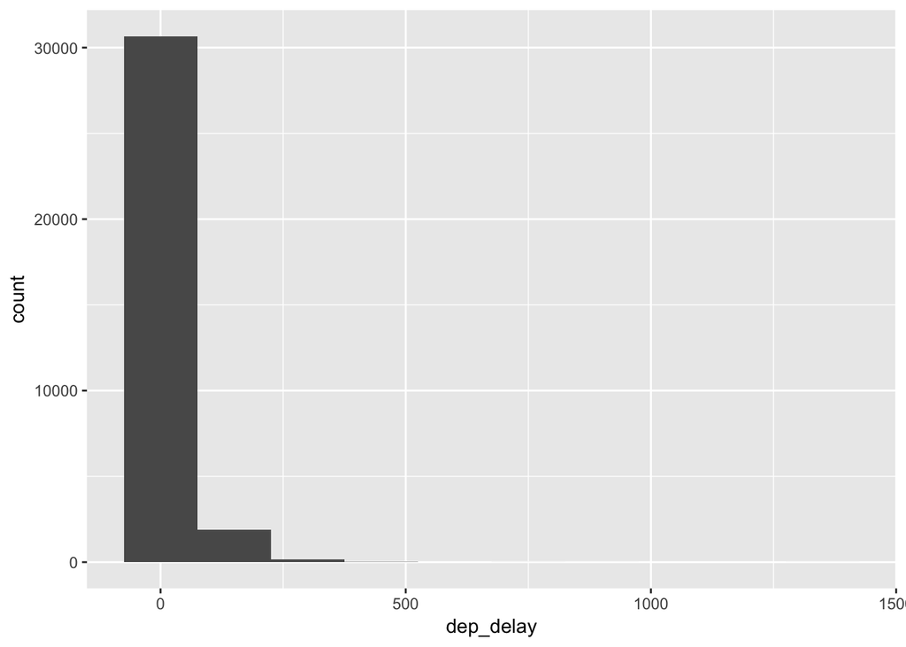

```r
ggplot(data = nycflights, aes(x = dep_delay)) +
  geom_histogram(binwidth = 150)
```

#### If we want to focus on departure delays of flights headed to RDU only, we need to first filter the data for flights headed to RDU (dest == “RDU”) and then make a histogram of only departure delays of only those flights.

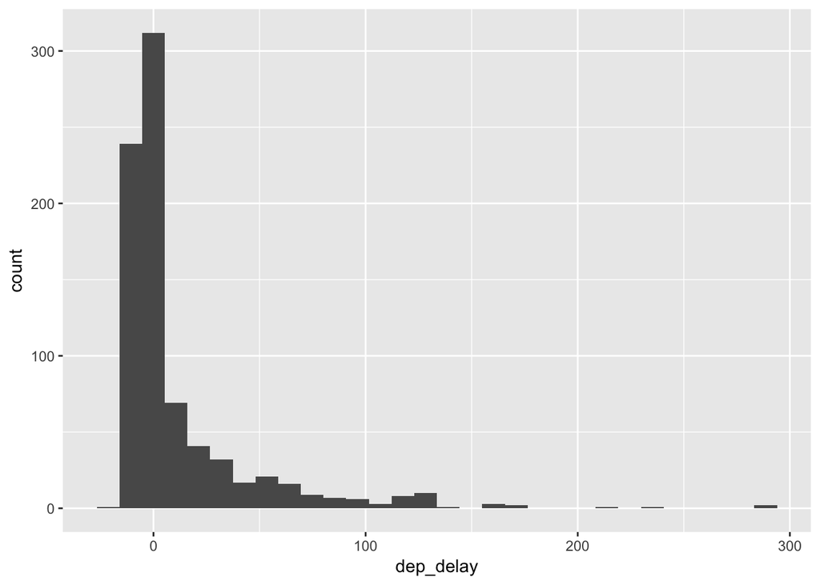

```r
rdu_flights <- nycflights %>% filter(dest == "RDU")
ggplot(data = rdu_flights, aes(x = dep_delay)) + geom_histogram()
```

```r
rdu_flights %>%
  summarise(mean_dd = mean(dep_delay), sd_dd = sd(dep_delay), n = n())
```

```
## # A tibble: 1 x 3
##   mean_dd sd_dd     n
##     <dbl> <dbl> <int>
## 1    11.7  35.6   801
```

#### We can also filter based on multiple criteria. Suppose we are interested in flights headed to San Francisco (SFO) in February:

```r
sfo_feb_flights <- nycflights %>%
  filter(dest == "SFO", month == 2)
```

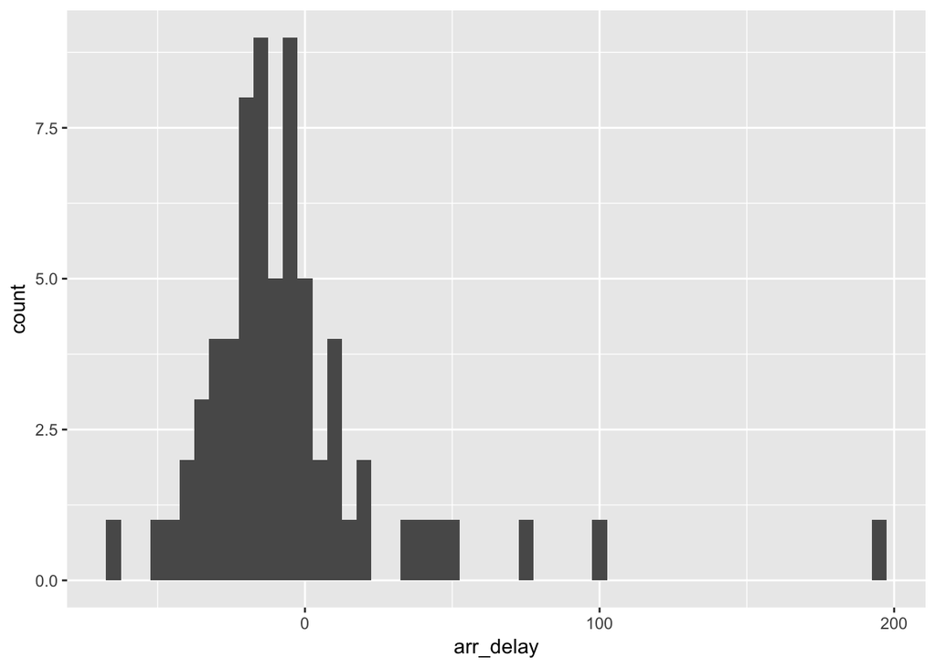

```r
ggplot(data=sfo_feb_flights,aes(x=arr_delay))+geom_histogram(binwidth=5)
```

```r
rdu_flights %>%
  group_by(origin) %>%
  summarise(mean_dd = mean(dep_delay), sd_dd = sd(dep_delay), n = n())
```

```
## # A tibble: 3 x 4
##   origin mean_dd sd_dd     n
##   <chr>    <dbl> <dbl> <int>
## 1 EWR      13.4   32.1   145
## 2 JFK      15.4   40.3   300
## 3 LGA       7.90  32.2   356
```

#### interquartile range for arr_delays of flights in the sfo_feb_flights data frame, grouped by carrier. Which carrier is the has the hights IQR of arrival delays?

```r
sfo_feb_flights %>% group_by(carrier) %>% summarise(iqr = IQR(arr_delay), med = median(arr_delay))
```

```
## # A tibble: 5 x 3
##   carrier   iqr    med
##   <chr>   <dbl>  <dbl>
## 1 AA       17.5   5.00
## 2 B6       12.2 -10.5
## 3 DL       22.0 -15.0
## 4 UA       22.0 -10.0
## 5 VX       21.2 -22.5
```

#### arrange these average delays in descending order

```r
nycflights %>%
  group_by(month) %>%
  summarise(mean_dd = mean(dep_delay)) %>%
  arrange(desc(mean_dd))
```

```
## # A tibble: 12 x 2
##    month mean_dd
##    <int>   <dbl>
##  1     7   20.8
##  2     6   20.4
##  3    12   17.4
##  4     4   14.6
##  5     3   13.5
##  6     5   13.3
##  7     8   12.6
##  8     2   10.7
##  9     1   10.2
## 10     9    6.87
## 11    11    6.10
## 12    10    5.88
```

#### Which month has the highest median departure delay from an NYC airport?

```r
nycflights %>%
  group_by(month) %>%
  summarise(median_dd = median(dep_delay)) %>%
  arrange(desc(median_dd))
```

```
## # A tibble: 12 x 2
##    month median_dd
##    <int>     <dbl>
##  1    12        1.
##  2     6        0.
##  3     7        0.
##  4     3       -1.
##  5     5       -1.
##  6     8       -1.
##  7     1       -2.
##  8     2       -2.
##  9     4       -2.
## 10    11       -2.
## 11     9       -3.
## 12    10       -3.
```

#### flight that is delayed for less than 5 minutes is basically “on time”. You consider any flight delayed for 5 minutes of more to be “delayed”.

Let’s start with classifying each flight as “on time” or “delayed” by creating a new variable with the mutate function.

```r
nycflights <- nycflights %>%
  mutate(dep_type = ifelse(dep_delay < 5, "on time", "delayed"))
```

mutate function is the name of the new variable we want to create, in this case dep_type.

dep_delay < 5 we classify the flight as “on time” and “delayed” if not, i.e. if the flight is delayed for 5 or more minutes.

overwriting the nycflights data frame with the new version of this data frame that includes the new dep_type variable.

```r
nycflights %>%
  group_by(origin) %>%
  summarise(ot_dep_rate = sum(dep_type == "on time") / n()) %>%
  arrange(desc(ot_dep_rate))
```

```
## # A tibble: 3 x 2
##   origin ot_dep_rate
##   <chr>        <dbl>
## 1 LGA          0.728
## 2 JFK          0.694
## 3 EWR          0.637
```

```r
nycflights %>%
  group_by(origin) %>%
  summarise(ot = sum(dep_delay<5)/n()) %>%
  arrange(desc(ot))
```

```
## # A tibble: 3 x 2
##   origin    ot
##   <chr>  <dbl>
## 1 LGA    0.728
## 2 JFK    0.694
## 3 EWR    0.637
```

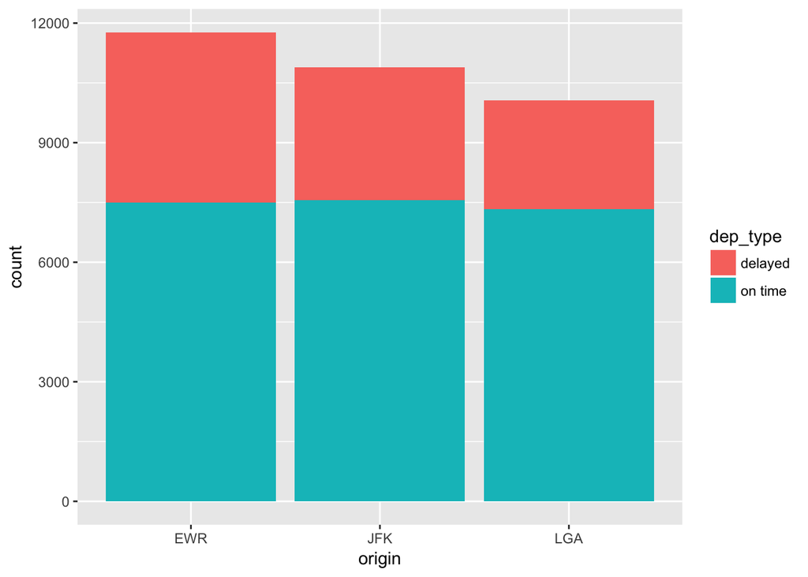

```r
ggplot(data = nycflights, aes(x = origin, fill = dep_type)) +
  geom_bar()
```

```r
nycflights <-nycflights %>%
  mutate(avg_speed=60*distance/air_time)

select(nycflights,tailnum, avg_speed) %>%
  arrange(desc(avg_speed))
```

```
## # A tibble: 32,735 x 2
##    tailnum avg_speed
##    <chr>       <dbl>
##  1 N666DN       703.
##  2 N779JB       557.
##  3 N571JB       554.
##  4 N568JB       548.
##  5 N5EHAA       548.
##  6 N656JB       548.
##  7 N789JB       545.
##  8 N516JB       539.
##  9 N648JB       536.
## 10 N510JB       536.
## # ... with 32,725 more rows
```

```r
nycflights %>%
  group_by(dep_type) %>%
  summarise(ot_rate = sum(arr_delay<=0)/n())
```

```
## # A tibble: 2 x 2
##   dep_type ot_rate
##   <chr>      <dbl>
## 1 delayed    0.183
## 2 on time    0.776
```